# Introduction

`bookdown+`? Hmm…sounds like something related to the R package `bookdown`?

Yes, you *R* right. Everyone knows that `bookdown` is an excellent package for authoring books on programing languages. But it is only one side of the coin. It can do more. `bookdown` smells like a tasty cake. I have been waiting and waiting, but nobody cuts it for me. Fine. Now I am helping myself. Therefore I am developing `bookdown+`.

`bookdown+` is an extension of `bookdown`. It is a collection of multiple templates, which I collected years ago on the basis of $\LaTeX$, and have been tailoring them so that I can work happily under the umbrella of `bookdown`. `bookdown+` shows you the other side of the coin, which helps you write academic journal articles, guitar books, chemical equations, mails, calendars, and diaries.

I believe some official bookdown templates will be available in the near future, but I cannot wait. Can you?

# Showcase

With `bookdown+` you can

- record guitar chords,

[figure not shown]

- write a mail in an elegant layout,

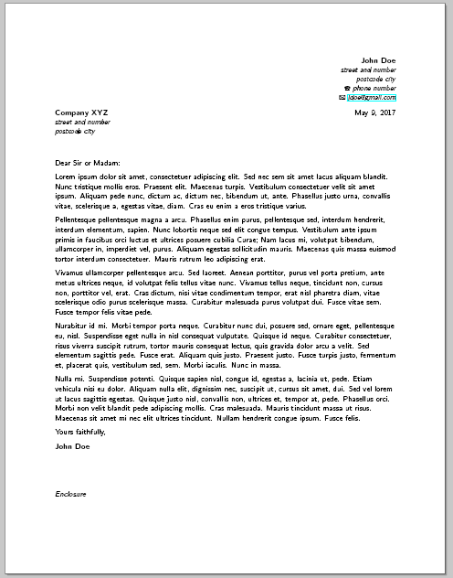

- write a laboratory journal, or a personal diary,

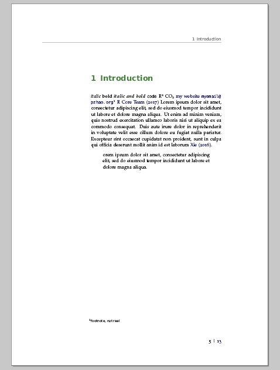

- draw a monthly or weekly or conference calendar,

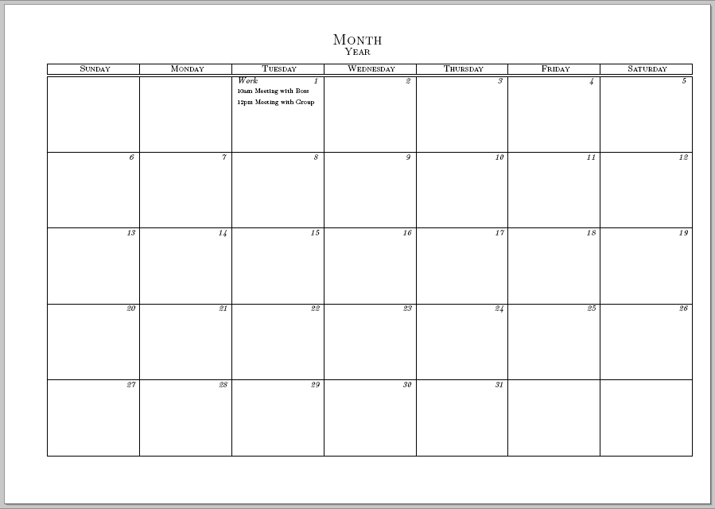

- and, of course, write academic articles in your favorate way,

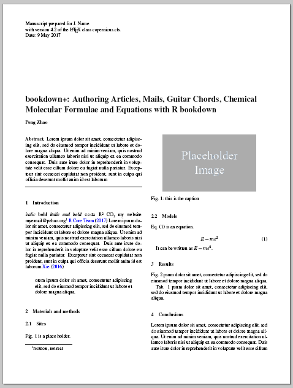

- with chemical molecular formulae and equations,

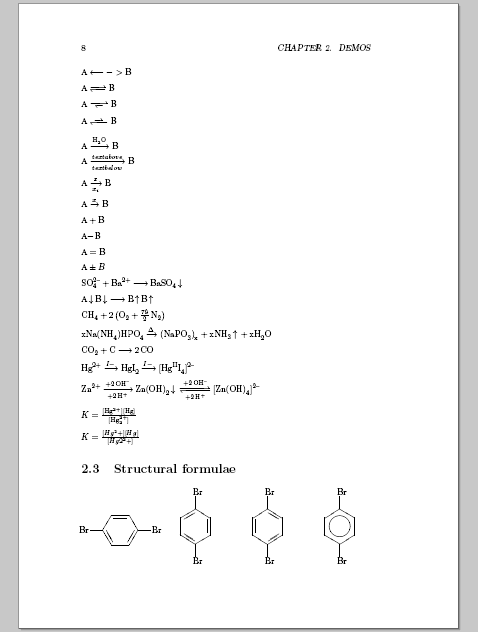

- even in Chinese,

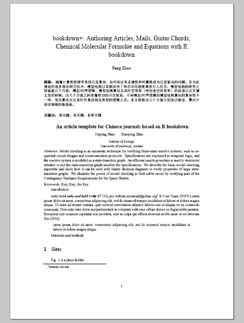

- and more wonders will come soon.

# Quick start

## Step 0. Preparation

Before starting, you have to install R, RStudio, bookdown package, and other software and packages (i.e. `Pandoc`, $\LaTeX$, `rmarkdown`, `rticle`, `knitr`, etc.) which bookdown depends on. See the [official manual of bookdown](https://bookdown.org/yihui/bookdown/) for details.

If you are ready, [download `bookdown+`](https://github.com/dapengde/bookdown-plus/archive/master.zip) package as a zip file from Github. Unzip it to a folder in your PC. You will find a file named `start.Rproj`. Double click it, and it will be opened by RStudio.

OK, now you can see a `_runme.R` file as well. Open it and run the script, or follow my explanation as follows,

## Step 1. Title and author

Specify the title and the author of your book, article, guitar book, or whatever.

```r
title <- 'bookdown+: Authoring Articles, Mails, Guitar books, Chemical Molecular Formulae and Equations with R bookdown'
author <- 'Peng Zhao'
```

## Step 2: Template

Choose a template out of the avaialble tempaltes.

```r
templates  <- c('article',     #1, academic article
                'article_zh',  #2, academic article in Chinese
                'calendar',    #3, calendar, in progress
                'chemistry',   #4, chemical molecular formulae and equations
                'chemistry_zh',#5, in Chinese,
                'guitar',      #6, guitar book
                'mail',        #7, mail, in progress
                'journal',     #8, laboratory journal, or personal diary
                'mini',        #9, a mini demo by Yihui
                'original',    #10, the original demo by Yihui
                'book_zh'      #11, the demo in Chinese by Yihui
)
template <- templates[8]
```

Run `fun/build.R`, and you will get necessary files for further editing.

```r
source('fun/build.R')
```

## Step 3: Write and Build

Now you can press `ctrl+shift+b` to build a template book, which you can find in `book/`.

Write your own text in `body.Rmd`, and build your own lovely book.

Have fun!

# Updates

- 2017-05-09, Version 0.1. A very preliminary version. This package is based on many other people’s excellent contributions, which I have not cited yet.